# Response to Reviewer 2: temporal and spatial dependence in H1

## Response to the reviewer

We thank the reviewer for raising the possibility that temporal trends within pollen records and spatial similarity among nearby records could influence the H1 comparison.

We agree that this concern required more than a brief explanation or a residual diagnostic on a small subset.

In response, we revised the main H1 analyses themselves.

Time is now included as a separate control within pollen records, space is included as a separate control when records are compared within time slices, and the main spatial summaries are additionally filtered for broad geographical structure.

Human activity and climate remain the ecological predictors of interest.

Time and space are structural controls that account for shared temporal and geographical patterns; we do not interpret them as additional causal drivers.

## How the main H1 analyses were changed

### Main spatial analysis: time within records and space among records

The analysis underlying the main spatial figure is fitted separately within each pollen record.

We now compare three predictor groups within every eligible record: human activity, climate, and time.

Including time prevents a long-term trend through a sediment sequence from being attributed automatically to either the human or climate predictors.

A pollen record has only one geographical location, so space cannot be estimated as a changing predictor within that record.

We therefore apply spatial filtering when the time-controlled results from different records are combined into continental, climate-zone, and global summaries.

The main figure retains one readily interpretable human-versus-climate balance for each record.

For this main presentation, negative hierarchical fractions are set to zero and the remaining positive human, climate, and temporal components are renormalised to sum to one.

The balance is the resulting human share minus climate share: negative values indicate greater relative importance of climate, zero indicates equal importance, and positive values indicate greater relative importance of human activity.

For the primary SPD analysis, the climate-dominated result was retained after adding time, after spatial filtering, in every 250-km and 500-km thinning repetition, and after omitting each continent and climate zone in turn.

Both calculation profiles had 100% thinning agreement and met the predeclared robust criterion.

| Profile | Before time and space controls | After time and space controls | Thinning agreement | Classification |
| --- | --- | --- | --- | --- |
| Signed contributions | -0.532 | -0.144 | 100% | robust |
| Bounded main-figure balance | -0.512 | -0.466 | 100% | robust |

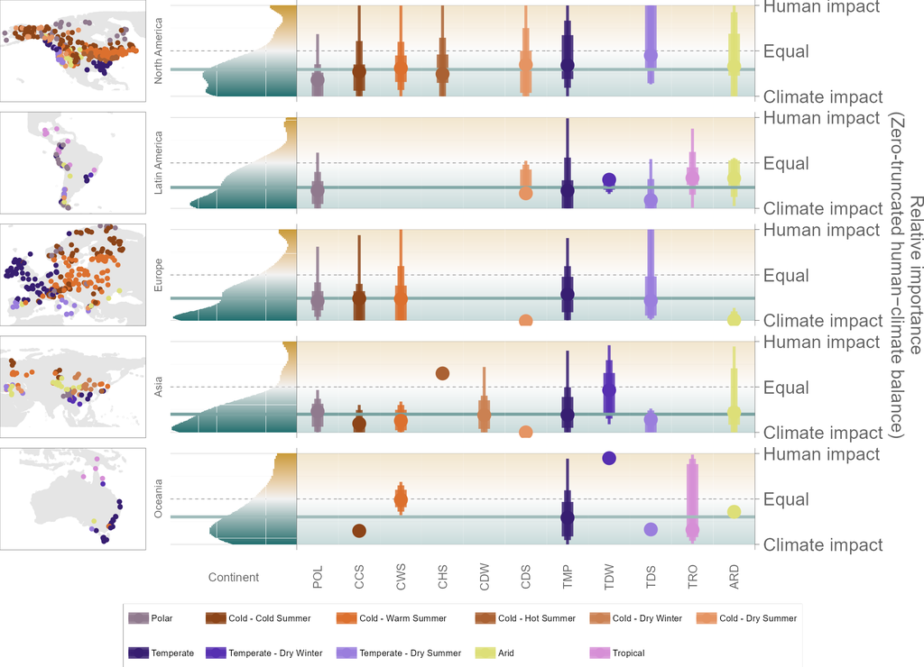

Main SPD result after controlling time within pollen records and filtering spatial structure when records are combined. Negative values indicate greater relative importance of climate.

### Main temporal analysis: space within each time slice

The temporal analysis compares many pollen records within each 500-year time slice.

We now fit human activity, climate, and broad spatial pattern as three separate predictor groups.

Spatial controls could be estimated in 46 SPD and 56 event-based region-by-age comparisons, and adding space caused 0 human-versus-climate ranking reversals. The revised main temporal figure shows human activity, climate, and space together; signed contributions and uniquely explained fractions remain available as supplementary diagnostics.

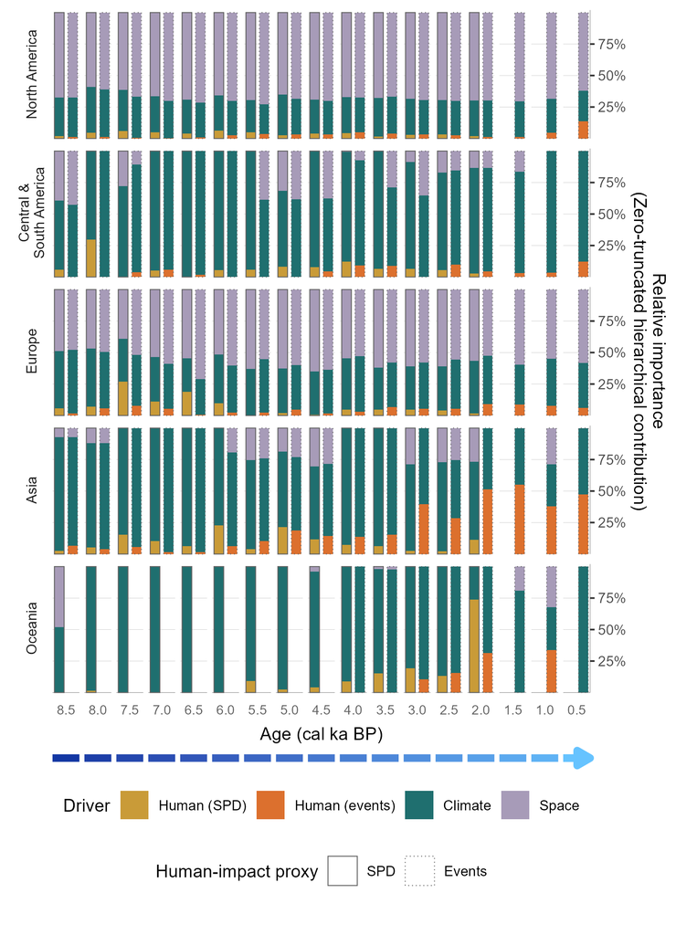

Shares of positive hierarchical contribution after adding space as a separate structural predictor within each 500-year time slice. Negative fractions were set to zero and each eligible bar was renormalised to sum to one. SPD is the primary human-activity proxy; event-based bars are supplementary.

## Why SPD remains primary and events remain supplementary

We agree with the reviewer that the pollen-derived human-impact events have important limitations.

The event chronology is based on expert interpretation of changes recorded in pollen data.

Using it to explain pollen assemblage properties therefore introduces circularity, and its broad categories cannot represent the full diversity, timing, or intensity of human activities within every region.

We have made this limitation explicit and do not treat the event analysis as evidence equivalent to the SPD analysis.

The SPD proxy is based on archaeological radiocarbon dates and is constructed independently of the pollen response.

It therefore remains the primary human-activity proxy and receives the complete spatial thinning, geographical leave-out, and formal robustness assessment.

We retain the events only as a supplementary comparison.

The SPD and event chronologies are two separately assembled sources of information about human activity, and the event chronology is independent of the construction of the archaeological SPD.

However, the event chronology is not independent of the pollen response itself.

Agreement between the two analyses therefore shows that the broad human-versus-climate conclusion is reproduced with an alternative human-activity chronology, but it should not be interpreted as a fully independent replication.

The supplementary event analysis nevertheless produced the same climate-dominated direction.

Its overall signed balance was -0.059, and its bounded presentation balance was -0.174.

No additional broad spatial terms were selected for the aggregated event balance.

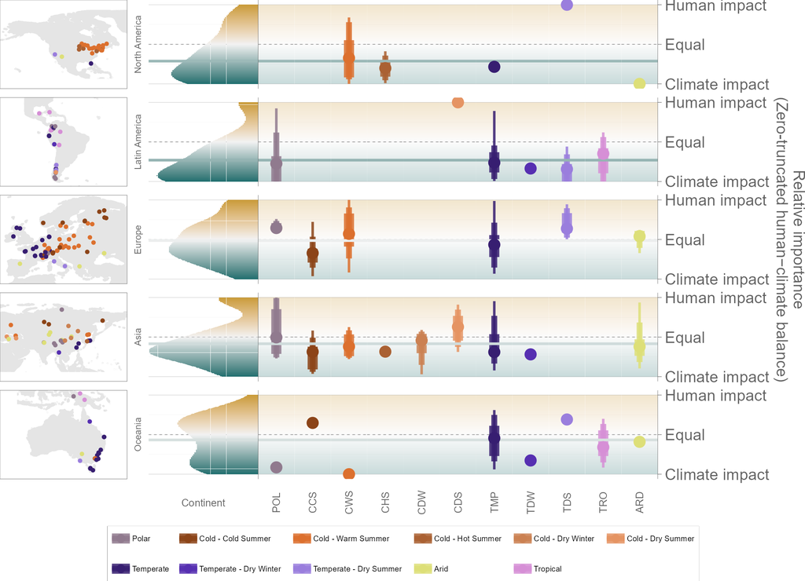

Supplementary event-based comparison after controlling time and testing broad spatial structure. The events are derived partly from pollen and are not independent of the pollen response.

## What the remaining autocorrelation means

Some temporal and spatial autocorrelation remains detectable after the controls.

Residual temporal structure was detected in 6 SPD and 1 event-based within-record models.

Residual spatial structure was detected in 50 SPD and 62 event-based region-by-age groups.

The relevant question, however, is whether this remaining structure changes the scientific conclusion.

It did not.

The climate-dominated result was retained after time control, spatial filtering, explicit spatial predictors, two spatial-thinning distances, every geographical leave-out check, and use of the alternative event chronology.

We therefore conclude that the greater relative importance of climate than human activity for broad-scale pollen assemblage dynamics is robust to temporal and spatial dependence at the scales evaluated here.

The event analysis supports this conclusion only as a supplementary comparison; the primary evidence and formal robustness classification remain based on the archaeological SPD analysis.